# Análise de Componentes Principais

Matheus Nunes Paiva

2024-05-12

# 1 Introdução

A Análise de Componentes Principais (ACP) é uma técnica estatística que permite simplificar a complexidade dos dados ao reduzir o número de dimensões sem perder a maior parte da informação original. Os componentes principais são os novos eixos que retêm a maior variância dos dados originais. A quantidade de variância mantida por cada componente é quantificada pelo autovalor ou valor próprio.

A ACP permite a visualização gráfica dos componentes principais, algo que é desafiador quando lidamos com mais de três variáveis. Esta técnica é particularmente útil quando temos um conjunto de variáveis altamente correlacionadas, indicando a presença de redundância nos dados. Uma correlação mais forte entre as variáveis permite que um menor número de componentes seja usado para explicar a maior parte da variância. Isso torna a ACP uma ferramenta poderosa para a simplificação e interpretação de dados complexos.

# 2 Carregando os pacotes

```r
library(tidyverse)
library(readr)
library(FactoMineR)
library(factoextra)
library(DT)
library(ggplot2)
library(ggcorrplot)
library(corrplot)
library(gt)
```

# 3 Carregando os dados

O conjunto de dados utilizado nesta análise contém informações sobre incêndios florestais na região de Montesinho, em Portugal. O conjunto de dados contém 517 observações e 13 variáveis, incluindo informações sobre a localização dos incêndios, o mês em que ocorreram, o tamanho do incêndio, o dia da semana, entre outras informações.

As variáveis são as seguintes:

1. X - coordenada espacial do eixo x dentro do mapa do parque Montesinho: 1 a 9
2. Y - coordenada espacial do eixo y dentro do mapa do parque Montesinho: 2 a 9
3. month - mês do ano: ‘jan’ a ‘dez’
4. day - dia da semana: ‘seg’ a ‘dom’
5. FFMC - índice FFMC do sistema FWI: 18.7 a 96.20
6. DMC - índice DMC do sistema FWI: 1.1 a 291.3
7. DC - índice DC do sistema FWI: 7.9 a 860.6
8. ISI - índice ISI do sistema FWI: 0.0 a 56.10
9. temp - temperatura em graus Celsius: 2.2 a 33.30
10. RH - umidade relativa em %: 15.0 a 100
11. wind - velocidade do vento em km/h: 0.40 a 9.40
12. rain- chuva externa em mm/m2: 0.0 a 6.4
13. área - a área queimada da floresta (em ha): 0.00 a 1090.84.

```r
dados <- read.csv("forestfires.csv", sep = ",")
datatable(dados,
           class = "row-border hover",
      options = list(
        scrollX = TRUE,
        dom = 'ltipr'
      ))
```

|  | X | Y | month | day | FFMC | DMC | DC | ISI | temp | RH | wind | rain | area |
| --- | --- | --- | --- | --- | --- | --- | --- | --- | --- | --- | --- | --- | --- |
| 1 | 7 | 5 | mar | fri | 86.2 | 26.2 | 94.3 | 5.1 | 8.2 | 51 | 6.7 | 0 | 0 |
| 2 | 7 | 4 | oct | tue | 90.6 | 35.4 | 669.1 | 6.7 | 18 | 33 | 0.9 | 0 | 0 |
| 3 | 7 | 4 | oct | sat | 90.6 | 43.7 | 686.9 | 6.7 | 14.6 | 33 | 1.3 | 0 | 0 |
| 4 | 8 | 6 | mar | fri | 91.7 | 33.3 | 77.5 | 9 | 8.3 | 97 | 4 | 0.2 | 0 |
| 5 | 8 | 6 | mar | sun | 89.3 | 51.3 | 102.2 | 9.6 | 11.4 | 99 | 1.8 | 0 | 0 |
| 6 | 8 | 6 | aug | sun | 92.3 | 85.3 | 488 | 14.7 | 22.2 | 29 | 5.4 | 0 | 0 |
| 7 | 8 | 6 | aug | mon | 92.3 | 88.9 | 495.6 | 8.5 | 24.1 | 27 | 3.1 | 0 | 0 |
| 8 | 8 | 6 | aug | mon | 91.5 | 145.4 | 608.2 | 10.7 | 8 | 86 | 2.2 | 0 | 0 |
| 9 | 8 | 6 | sep | tue | 91 | 129.5 | 692.6 | 7 | 13.1 | 63 | 5.4 | 0 | 0 |
| 10 | 7 | 5 | sep | sat | 92.5 | 88 | 698.6 | 7.1 | 22.8 | 40 | 4 | 0 | 0 |

[output cut: 507 more lines]

Vamos extrair apenas as variáveis numéricas para a análise.

```r
dados_num <- dados[,c(5:13)]
datatable(dados_num,
           class = "row-border hover",
      options = list(
        scrollX = TRUE,
        dom = 'ltipr'
      ))
```

|  | FFMC | DMC | DC | ISI | temp | RH | wind | rain | area |
| --- | --- | --- | --- | --- | --- | --- | --- | --- | --- |
| 1 | 86.2 | 26.2 | 94.3 | 5.1 | 8.2 | 51 | 6.7 | 0 | 0 |
| 2 | 90.6 | 35.4 | 669.1 | 6.7 | 18 | 33 | 0.9 | 0 | 0 |
| 3 | 90.6 | 43.7 | 686.9 | 6.7 | 14.6 | 33 | 1.3 | 0 | 0 |
| 4 | 91.7 | 33.3 | 77.5 | 9 | 8.3 | 97 | 4 | 0.2 | 0 |
| 5 | 89.3 | 51.3 | 102.2 | 9.6 | 11.4 | 99 | 1.8 | 0 | 0 |
| 6 | 92.3 | 85.3 | 488 | 14.7 | 22.2 | 29 | 5.4 | 0 | 0 |
| 7 | 92.3 | 88.9 | 495.6 | 8.5 | 24.1 | 27 | 3.1 | 0 | 0 |
| 8 | 91.5 | 145.4 | 608.2 | 10.7 | 8 | 86 | 2.2 | 0 | 0 |
| 9 | 91 | 129.5 | 692.6 | 7 | 13.1 | 63 | 5.4 | 0 | 0 |
| 10 | 92.5 | 88 | 698.6 | 7.1 | 22.8 | 40 | 4 | 0 | 0 |

[output cut: 507 more lines]

# 4 Alguns resultados preliminares

## 4.1 Matriz de correlação

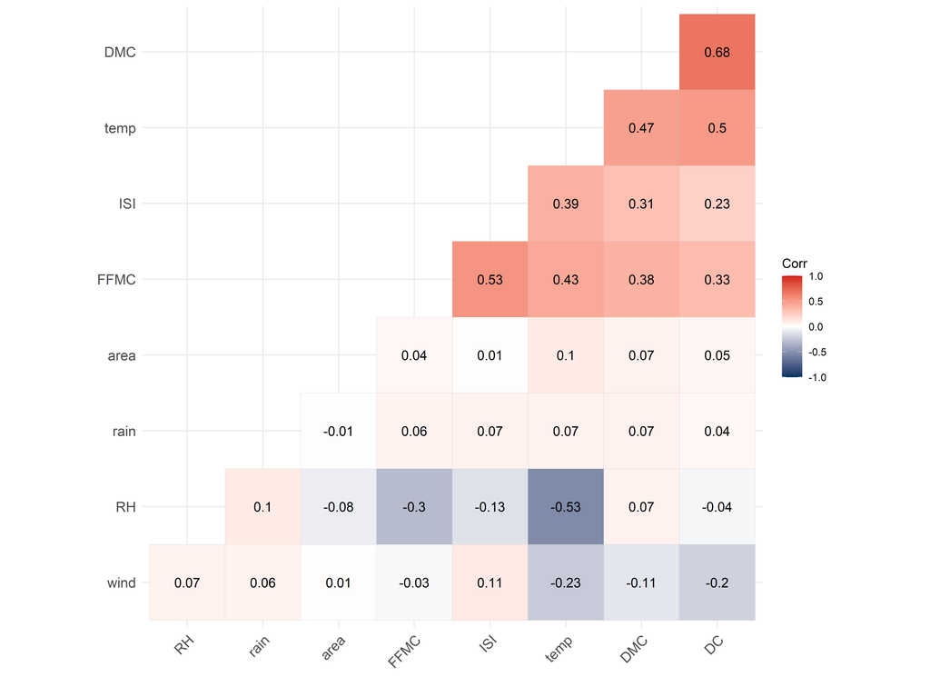

```r
 ggcorrplot(
            cor(dados_num),
            hc.order = T,
            type = "lower",
            lab = T,
            colors = c("#003262", "#FFFFFF", "#D21E1C")
          )
```

Pela matriz de correlação é possível observar que a maioria das variáveis estão fracamente correlacionadas entre si, o que pode ser ruim para a análise de componentes principais, pois quanto mais correlacionadas as variáveis, mais fácil é a interpretação dos componentes.

## 4.2 Matriz de variância-covariância

```r
Mcov<-cov(dados_num)
Mcov<-round(Mcov, 4)
datatable(Mcov,
           class = "row-border hover",
      options = list(
        scrollX = TRUE,
        dom = 'ltipr'
      ))
```

|  | FFMC | DMC | DC | ISI | temp | RH | wind | rain | area |
| --- | --- | --- | --- | --- | --- | --- | --- | --- | --- |
| FFMC | 30.4716 | 135.2725 | 452.5873 | 13.3849 | 13.832 | -27.1119 | -0.2817 | 0.0926 | 14.0984 |
| DMC | 135.2725 | 4101.9519 | 10838.5013 | 89.103 | 174.6391 | 77.1214 | -12.0879 | 1.4177 | 297.5927 |
| DC | 452.5873 | 10838.5013 | 61536.8355 | 259.1853 | 714.7517 | -158.6404 | -90.43 | 2.6328 | 779.8034 |
| ISI | 13.3849 | 89.103 | 259.1853 | 20.7888 | 10.4388 | -9.8592 | 0.8727 | 0.0913 | 2.3967 |
| temp | 13.832 | 174.6391 | 714.7517 | 10.4388 | 33.7169 | -49.9699 | -2.3628 | 0.1194 | 36.1657 |
| RH | -27.1119 | 77.1214 | -158.6404 | -9.8592 | -49.9699 | 266.2598 | 2.0292 | 0.4817 | -78.4413 |
| wind | -0.2817 | -12.0879 | -90.43 | 0.8727 | -2.3628 | 2.0292 | 3.21 | 0.0324 | 1.4048 |
| rain | 0.0926 | 1.4177 | 2.6328 | 0.0913 | 0.1194 | 0.4817 | 0.0324 | 0.0876 | -0.1388 |
| area | 14.0984 | 297.5927 | 779.8034 | 2.3967 | 36.1657 | -78.4413 | 1.4048 | -0.1388 | 4052.0632 |

# 5 Análise de Componentes Principais

```r
res.pca<-PCA(dados_num, graph = F)
eig.val <- as.data.frame(get_eigenvalue(res.pca))
row.names(eig.val) <- c("Componente.1", "Componente.2", "Componente.3", "Componente.4", "Componente.5", "Componente.6", "Componente.7", "Componente.8", "Componente.9")
nomes<-rownames(eig.val)
eig.val<-cbind(nomes, eig.val)
colnames(eig.val)<-c("Componente", "Autovalor", "Percentual", "Acumulado")
gt(eig.val) %>%
  tab_header(title = "Resumo dos componentes") %>%
  fmt_number(columns = c(2:4), decimals = 4) %>%
  opt_stylize(style = 3, color = "blue") %>%
  tab_options(table.width ="500px")
```

Resumo dos componentes

| Componente | Autovalor | Percentual | Acumulado |
| --- | --- | --- | --- |
| Componente.1 | 2.8545 | 31.7171 | 31.7171 |
| Componente.2 | 1.3090 | 14.5445 | 46.2616 |
| Componente.3 | 1.2211 | 13.5677 | 59.8293 |
| Componente.4 | 0.9997 | 11.1082 | 70.9374 |
| Componente.5 | 0.9365 | 10.4055 | 81.3429 |
| Componente.6 | 0.6835 | 7.5940 | 88.9369 |
| Componente.7 | 0.4723 | 5.2473 | 94.1842 |
| Componente.8 | 0.3075 | 3.4171 | 97.6013 |
| Componente.9 | 0.2159 | 2.3987 | 100.0000 |

A tabela resumo dos componentes apresenta os autovalores, o percentual de variância explicada por cada componente e o percentual acumulado de variância explicada.

O ideal é selecionar os componentes que possuem autovalores maiores que 1, pois estes são os componentes que explicam mais variância do que uma variável original, ou também selecionar os componentes que explicam no mínimo 70% da variância total.

Para este exemplo irei utilizar os 5 primeiros componentes.

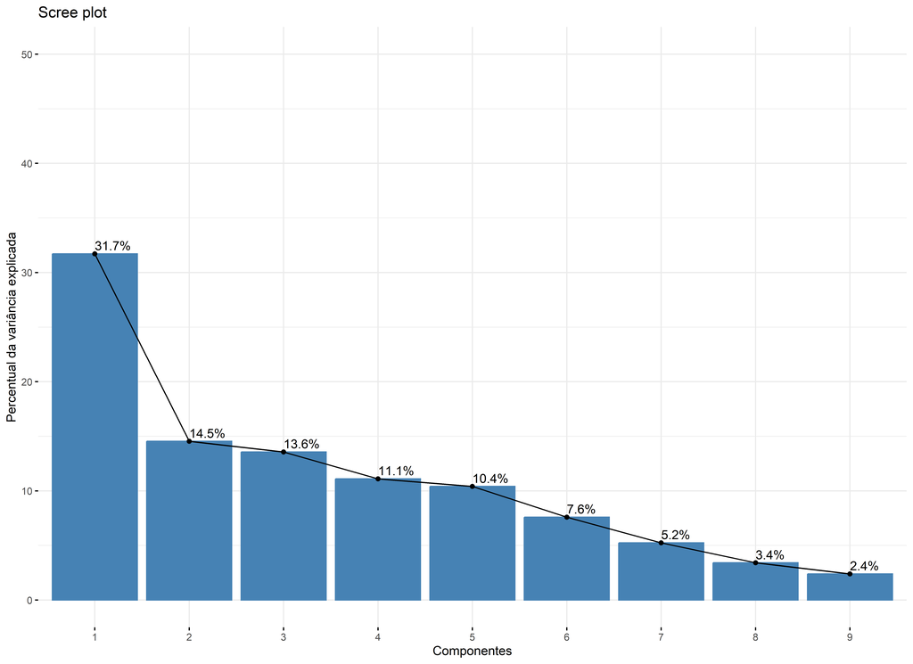

```r
fviz_eig(res.pca, addlabels = TRUE, xlab='Componentes', ylab = 'Percentual da variância explicada', ylim = c(0, 50))
```

Acima está o gráfico de autovalores, que mostra a quantidade de variância explicada por cada componente.

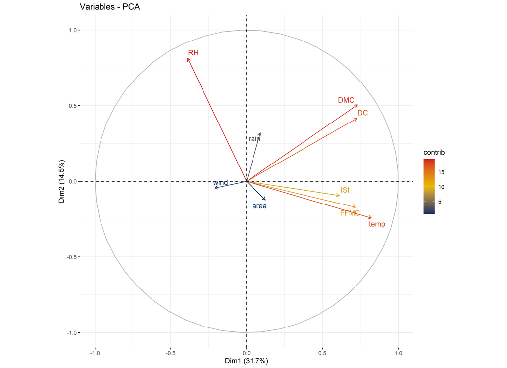

```r
fviz_pca_var(res.pca, col.var = "contrib",
             axes = c(1, 2),
             gradient.cols = c("#003262", "#E7B800", "#D21E1C"),
             repel = TRUE
)
```

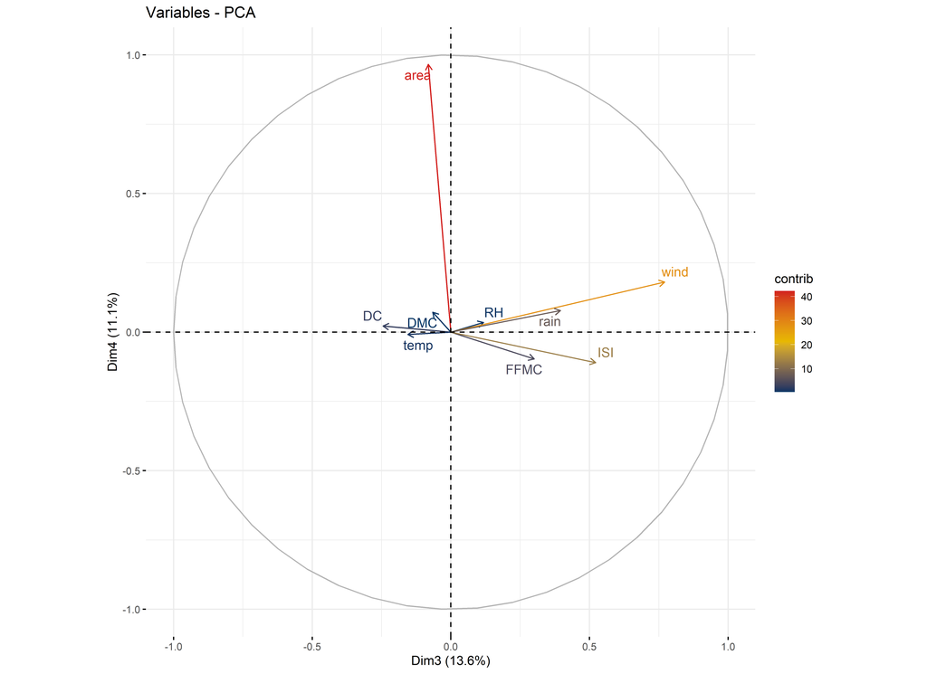

```r
fviz_pca_var(res.pca, col.var = "contrib",
             axes = c(3, 4),
             gradient.cols = c("#003262", "#E7B800", "#D21E1C"),
             repel = TRUE
)
```

Acima estão 2 gráficos para os componentes 1 e 2 e 3 e 4, respectivamente. Os gráficos mostram a contribuição de cada variável para a formação dos componentes, quanto menor a reta que liga a variável ao componente, menor é a contribuição da variável para a formação do componente.

O ideal seria plotar um gráfico para cada combinação de componentes, mas para este exemplo irei plotar apenas para os componentes 1 e 2 e 3 e 4.

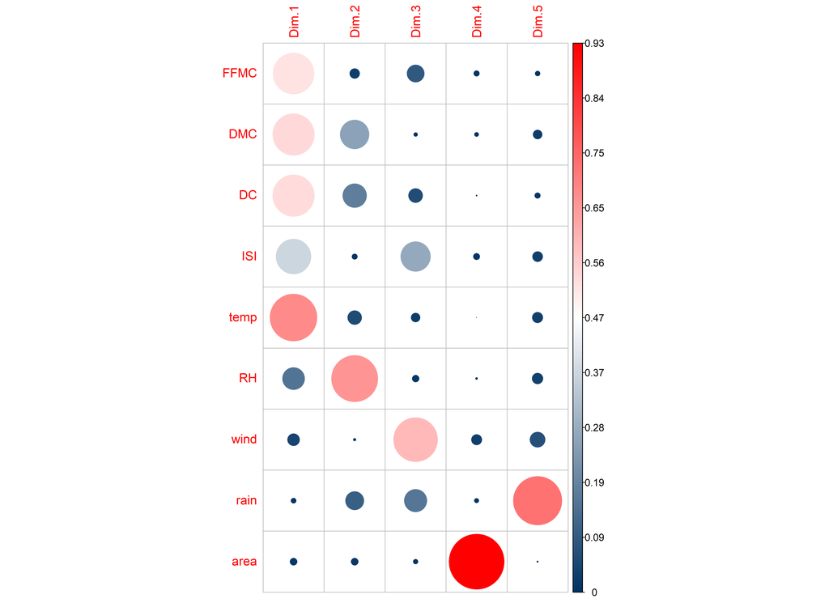

```r
colors = c("#003262", "#FFFFFF", "#FF0000")
pal = colorRampPalette(colors)
grad_colors = pal(1000)
corrplot(res.pca$var$cos2, is.corr=FALSE, col=grad_colors)
```

O gráfico acima mostra a contribuição de cada variável para a formação dos componentes. Quanto mais próximo de 1, maior é a contribuição da variável para a formação do componente.

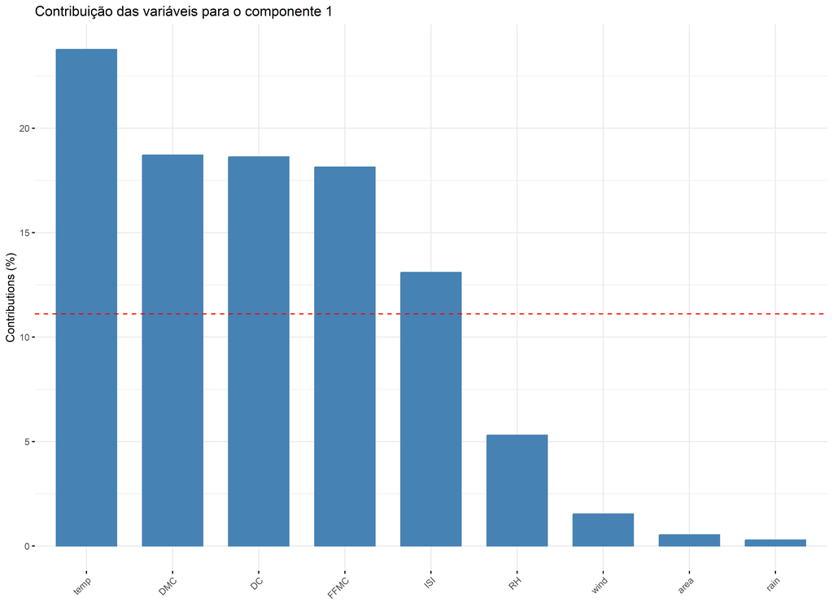

```r
fviz_contrib(res.pca, choice = "var", axes = 1, top = 10,
             title ="Contribuição das variáveis para o componente 1"
)
```

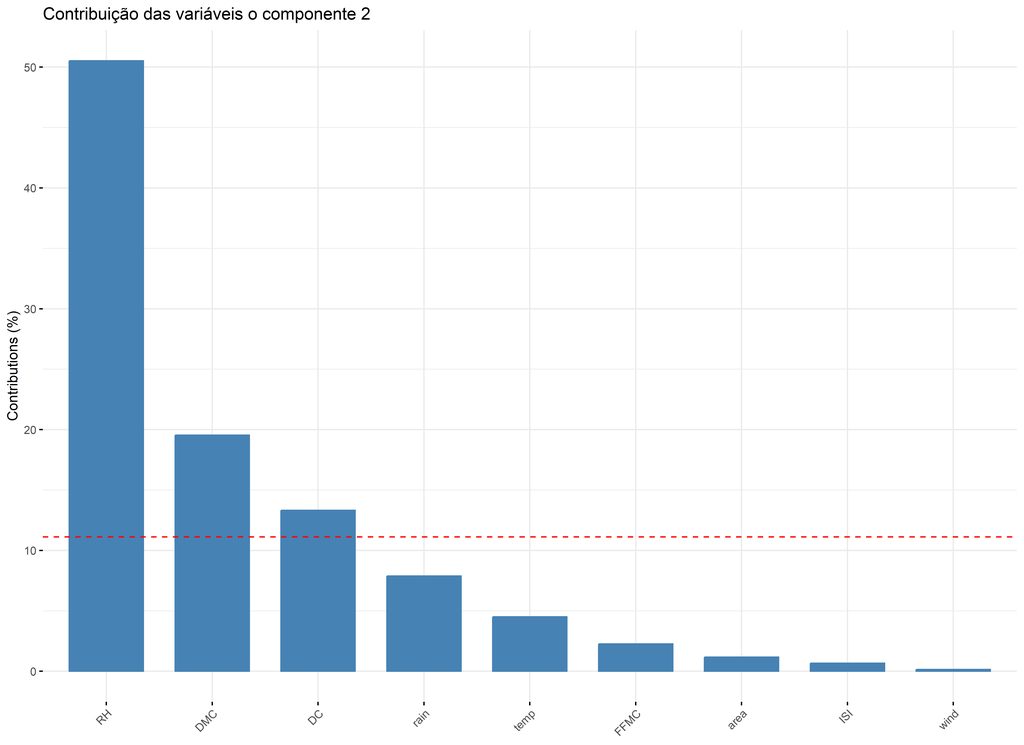

```r
fviz_contrib(res.pca, choice = "var", axes = 2, top = 10,
             title ="Contribuição das variáveis o componente 2"
)
```

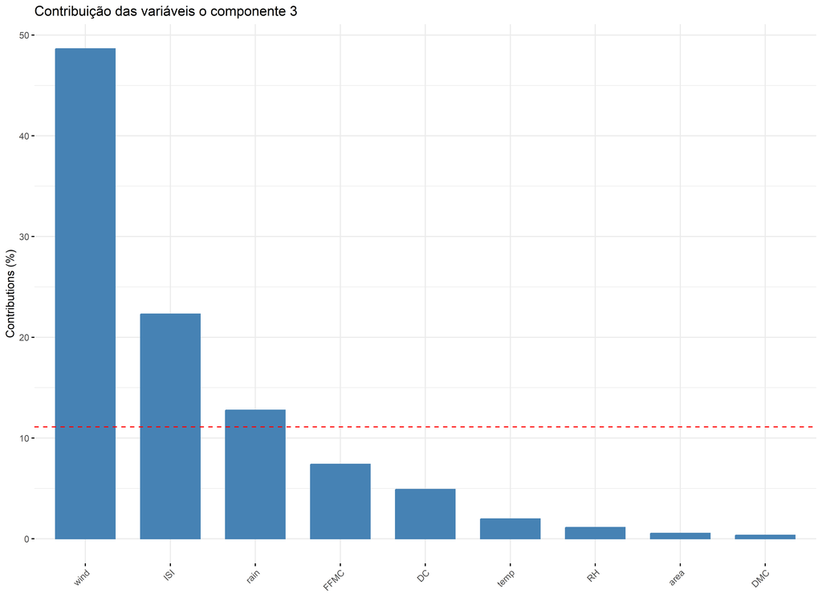

```r
fviz_contrib(res.pca, choice = "var", axes = 3, top = 10,
             title ="Contribuição das variáveis o componente 3"
)
```

Os gráficos acima mostram a contribuição de cada variável para a formação dos componentes. Quanto mais próximo de 1, maior é a contribuição da variável para a formação do componente. A linha tracejada em vermelho é o valor esperado de contribuição, ou seja, 1/número de variáveis. Para este exemplo eu plotei apenas para os componentes 1, 2 e 3.

# 6 Referências

Cortez,Paulo and Morais,Anbal. (2008). Forest Fires. UCI Machine Learning Repository. https://doi.org/10.24432/C5D88D.